# 数据分析文档

## Week 2：Uber平台与竞品价格因素分析

- 行程长度和价格的关系;
- 行程价格与气候的关系;
- 行程类型与价格的关系;

同时尝试总结，在时域和空域上这些数据的特征。比如，早晨常见的迁移方向是什么？傍晚常见的迁移方向是什么？工作日的行程和周末的行程特征是否有具体区别？等等等等，总结出一个报告，尝试给出针对司机优化运营的统计和方案。

### 数据预处理

首先导入数据，然后将时间戳转换为时间类型数据,并去除包含缺失值的记录。

```python
import pandas as pd
import numpy as np
from time import localtime,strftime
import matplotlib.pyplot as plt
import matplotlib
matplotlib.rcParams['axes.unicode_minus']=False #显示负号
plt.rcParams['font.sans-serif']=['SimHei'] #中文显示
data1 = pd.read_csv(r"weather.csv")#气象数据
data2 = pd.read_csv(r"cab_rides.csv")#行程数据
#将两个表格中的时间戳转换成时间数据
def get_date(t):
    if len(str(t))==10:
        times = strftime("%Y-%m-%d %H:%M:%S",localtime(t))
    else:
        times = strftime("%Y-%m-%d %H:%M:%S",localtime(t/1000))
    return times
data1["time_stamp"] = data1["time_stamp"].apply(get_date)
data2["time_stamp"] = data2["time_stamp"].apply(get_date)
data1 = data1.dropna()
data2 = data2.dropna()
```

### 一、行程长度和价格的关系；

```python
data = data2[["distance","price","cab_type"]]
```

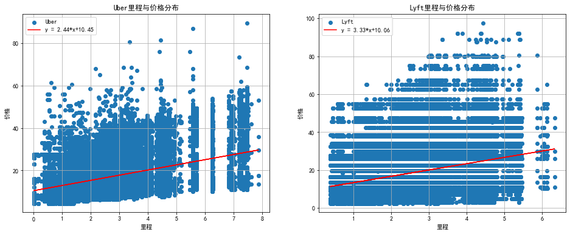

```python
from scipy import stats
plt.figure(figsize=(16,6))
x1 = data[data["cab_type"]=="Uber"]["distance"].tolist()
y1 = data[data["cab_type"]=="Uber"]["price"].tolist()
slope,intercept,r,p,std_err = stats.linregress(x1,y1)
def myfunc(x):
    return slope*x+intercept
mymodel1 = list(map(myfunc,x1))
plt.subplot(1,2,1)
plt.scatter(x1,y1)
plt.plot(x1,mymodel1,color="r")
plt.grid()
plt.xlabel("里程")
plt.ylabel("价格")
plt.title("Uber里程与价格分布")
plt.legend(["Uber","y = %s*x+%s"%(round(slope,2),round(intercept,2))])

plt.subplot(1,2,2)
x2 = data[data["cab_type"]=="Lyft"]["distance"].tolist()
y2 = data[data["cab_type"]=="Lyft"]["price"].tolist()
slope,intercept,r,p,std_err = stats.linregress(x2,y2)
def myfunc(x):
    return slope*x+intercept
mymodel2 = list(map(myfunc,x2))
plt.scatter(x2,y2)
plt.plot(x2,mymodel2,color="r")
plt.grid()
plt.xlabel("里程")
plt.ylabel("价格")
plt.title("Lyft里程与价格分布")
plt.legend(["Lyft","y = %s*x+%s"%(round(slope,2),round(intercept,2))])
plt.show()
```

### 二、行程价格与气候的关系；

根据行程记录表中的出发地，匹配气候表中该地点时间最接近的气候数据。

```python
from datetime import datetime
data = []
for i in data2.sample(10000).values:#从行程表中随机抽取10000条记录进行分析
    distance = i[0]
    source = i[4]
    price = i[5]
    cab_type = i[1]
    T = i[2]
    times=[]
    d = data1[data1["location"]==source]
    for j in d.values:
        abj = datetime.strptime(T,"%Y-%m-%d %H:%M:%S")-datetime.strptime(j[5],"%Y-%m-%d %H:%M:%S")
        times.append(abs(abj.total_seconds()))
    value = d.values[times.index(min(times))]
    data.append([distance,cab_type,source,price,T,value[0],value[2],value[3],value[4],value[6],value[7]])
data = pd.DataFrame(data,columns=["distance","cab_type","source","price","time_stamp","temp","clouds",
                                  "pressure","rain","humidity","wind"])
```

```python
data#查看价格与气候数据
```

|  | distance | cab_type | source | price | time_stamp | temp | clouds | pressure | rain | humidity | wind |
| --- | --- | --- | --- | --- | --- | --- | --- | --- | --- | --- | --- |
| 0 | 0.71 | Lyft | Theatre District | 16.5 | 2018-11-29 11:56:07 | 38.22 | 0.50 | 997.93 | 0.0020 | 0.71 | 10.44 |
| 1 | 4.23 | Lyft | Northeastern University | 27.5 | 2018-12-01 07:32:58 | 37.88 | 1.00 | 1020.05 | 0.0193 | 0.86 | 1.85 |
| 2 | 1.14 | Lyft | South Station | 27.5 | 2018-12-03 16:42:57 | 51.24 | 0.89 | 1000.10 | 0.0062 | 0.86 | 4.53 |
| 3 | 0.56 | Uber | North Station | 16.0 | 2018-11-27 09:03:23 | 44.02 | 0.98 | 1006.00 | 0.1554 | 0.90 | 9.99 |
| 4 | 2.93 | Lyft | North End | 22.5 | 2018-11-26 22:05:10 | 42.67 | 0.91 | 1014.85 | 0.0030 | 0.90 | 2.23 |
| ... | ... | ... | ... | ... | ... | ... | ... | ... | ... | ... | ... |
| 9995 | 0.64 | Lyft | South Station | 27.5 | 2018-12-03 10:13:00 | 48.86 | 0.99 | 1005.88 | 0.0030 | 0.93 | 3.95 |
| 9996 | 1.44 | Uber | Back Bay | 8.5 | 2018-12-01 05:28:07 | 37.42 | 0.93 | 1017.88 | 0.0020 | 0.67 | 3.03 |
| 9997 | 2.50 | Uber | South Station | 16.5 | 2018-12-01 01:23:01 | 37.37 | 0.93 | 1017.88 | 0.0029 | 0.67 | 3.18 |
| 9998 | 3.09 | Uber | Fenway | 10.5 | 2018-12-03 02:52:56 | 48.35 | 0.99 | 1006.04 | 0.0059 | 0.93 | 3.95 |
| 9999 | 0.91 | Uber | Haymarket Square | 27.5 | 2018-12-16 07:20:10 | 42.35 | 0.91 | 1018.92 | 0.0080 | 0.73 | 9.47 |

10000 rows × 11 columns

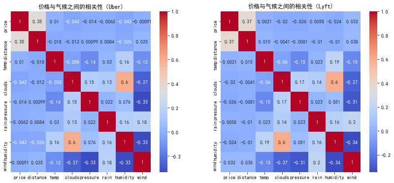

```python
import seaborn as sns
plt.figure(figsize=(14,6))
plt.subplot(1,2,1)
train = data[data["cab_type"]=="Uber"][["price","distance","temp","clouds","pressure","rain","humidity","wind"]]
sns.heatmap(train.corr(),annot=True,cmap="coolwarm")
plt.title("价格与气候之间的相关性（Uber)")

plt.subplot(1,2,2)
train = data[data["cab_type"]=="Lyft"][["price","distance","temp","clouds","pressure","rain","humidity","wind"]]
sns.heatmap(train.corr(),annot=True,cmap="coolwarm")
plt.title("价格与气候之间的相关性（Lyft)")
plt.show()
```

### 三、行程类型与价格的关系；

根据上述价格对行程长度和气候的关系分析，由于气候与价格相关性较低；因此只限定相同行程长度的情况下，对不同行程类型与价格的关系进行分析，本次分析限定行程长度为1公里。

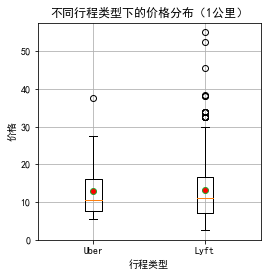

```python
data = data2[data2["distance"]==1]
Y1 = data[data["cab_type"]=="Uber"]["price"]#Uber
Y2 = data[data["cab_type"]=="Lyft"]["price"]#Lyft
plt.figure(figsize=(4,4))
plt.boxplot(x=[Y1,Y2],
            showmeans=True,
            labels=["Uber","Lyft"],
            meanprops={"marker":"o","markerfacecolor":"red"})
plt.ylabel("价格")
plt.xlabel("行程类型")
plt.title("不同行程类型下的价格分布（1公里）")
plt.grid()
plt.show()
```

### 四、行程记录的时空特征分析

```python
def get_Hour(t):#获取小时，0-24代表各个小时
    t = datetime.strptime(t,"%Y-%m-%d %H:%M:%S")
    return t.hour
def get_Weekday(t):#获取星期，0-6表示周1-周日
    t = datetime.strptime(t,"%Y-%m-%d %H:%M:%S")
    return t.weekday()
data2["Hour"] = data2["time_stamp"].apply(get_Hour)
data2["WeekDay"] = data2["time_stamp"].apply(get_Weekday)
```

#### 1、上午7点到10点的行程特征

```python
#提取上午07-10点的行程记录
data = data2[data2["Hour"].isin([7,8,9])]
data
```

|  | distance | cab_type | time_stamp | destination | source | price | surge_multiplier | id | product_id | name | Hour | WeekDay |
| --- | --- | --- | --- | --- | --- | --- | --- | --- | --- | --- | --- | --- |
| 2 | 0.44 | Lyft | 2018-11-28 09:00:22 | North Station | Haymarket Square | 7.0 | 1.0 | 981a3613-77af-4620-a42a-0c0866077d1e | lyft | Lyft | 9 | 2 |
| 15 | 1.11 | Uber | 2018-12-17 07:55:11 | West End | North End | 7.5 | 1.0 | 50ef1165-9d23-416c-a65c-18906207b295 | 9a0e7b09-b92b-4c41-9779-2ad22b4d779d | WAV | 7 | 0 |
| 16 | 1.11 | Uber | 2018-12-14 08:40:07 | West End | North End | 26.0 | 1.0 | 91c4861c-1780-42b0-bca1-bbd64a422cc3 | 6d318bcc-22a3-4af6-bddd-b409bfce1546 | Black SUV | 8 | 4 |
| 36 | 3.24 | Lyft | 2018-12-14 08:30:10 | Northeastern University | North Station | 16.5 | 1.0 | e61386a3-b205-49b4-b064-990b124ecfa2 | lyft_plus | Lyft XL | 8 | 4 |
| 46 | 1.76 | Lyft | 2018-12-16 08:40:11 | South Station | North Station | 16.5 | 1.0 | 1cf8a0a5-d871-41ba-91c7-53658851501e | lyft_premier | Lux | 8 | 6 |
| ... | ... | ... | ... | ... | ... | ... | ... | ... | ... | ... | ... | ... |
| 693065 | 1.00 | Uber | 2018-12-02 07:53:05 | North End | West End | 9.5 | 1.0 | 353e6566-b272-479e-a9c6-98bd6cb23f25 | 9a0e7b09-b92b-4c41-9779-2ad22b4d779d | WAV | 7 | 6 |
| 693066 | 1.00 | Uber | 2018-12-02 07:53:05 | North End | West End | 13.0 | 1.0 | 616d3611-1820-450a-9845-a9ff304a4842 | 6f72dfc5-27f1-42e8-84db-ccc7a75f6969 | UberXL | 7 | 6 |
| 693067 | 1.00 | Uber | 2018-12-02 07:53:05 | North End | West End | 9.5 | 1.0 | 633a3fc3-1f86-4b9e-9d48-2b7132112341 | 55c66225-fbe7-4fd5-9072-eab1ece5e23e | UberX | 7 | 6 |
| 693069 | 1.00 | Uber | 2018-12-02 07:53:05 | North End | West End | 27.0 | 1.0 | 727e5f07-a96b-4ad1-a2c7-9abc3ad55b4e | 6d318bcc-22a3-4af6-bddd-b409bfce1546 | Black SUV | 7 | 6 |
| 693070 | 1.00 | Uber | 2018-12-02 07:53:05 | North End | West End | 10.0 | 1.0 | e7fdc087-fe86-40a5-a3c3-3b2a8badcbda | 997acbb5-e102-41e1-b155-9df7de0a73f2 | UberPool | 7 | 6 |

85537 rows × 12 columns

```python
destination = {}#出发地->目的地组合
for i in data.values:
    if i[4]+"=>"+i[3] not in destination:
        destination[i[4]+"=>"+i[3]] = 1
    else:
        destination[i[4]+"=>"+i[3]] += 1
print("出发地=>目的地：数量")
sorted(destination.items(),key=lambda item:item[1],reverse=True)[:10]
```

```
出发地=>目的地：数量
```

```
[('South Station=>Financial District', 1362),
 ('Boston University=>West End', 1303),
 ('Fenway=>West End', 1297),
 ('Back Bay=>North End', 1293),
 ('Financial District=>South Station', 1272),
 ('Boston University=>Financial District', 1272),
 ('North Station=>Northeastern University', 1270),
 ('West End=>Boston University', 1263),
 ('Haymarket Square=>Theatre District', 1252),
 ('Back Bay=>South Station', 1252)]
```

#### 2、下午5点到晚上8点的行程特征

```python
#提取下午午17-20点的行程记录
data = data2[data2["Hour"].isin([17,18,19])]
data
```

|  | distance | cab_type | time_stamp | destination | source | price | surge_multiplier | id | product_id | name | Hour | WeekDay |
| --- | --- | --- | --- | --- | --- | --- | --- | --- | --- | --- | --- | --- |
| 0 | 0.44 | Lyft | 2018-12-16 17:30:07 | North Station | Haymarket Square | 5.0 | 1.0 | 424553bb-7174-41ea-aeb4-fe06d4f4b9d7 | lyft_line | Shared | 17 | 6 |
| 9 | 1.08 | Lyft | 2018-11-27 18:45:22 | Northeastern University | Back Bay | 27.5 | 1.0 | 8612d909-98b8-4454-a093-30bd48de0cb3 | lyft_luxsuv | Lux Black XL | 18 | 1 |
| 13 | 1.11 | Uber | 2018-12-13 18:50:11 | West End | North End | 16.0 | 1.0 | 23f145da-f0c1-4d1f-a184-496bc003a7db | 6c84fd89-3f11-4782-9b50-97c468b19529 | Black | 18 | 3 |
| 21 | 0.72 | Lyft | 2018-12-18 19:35:05 | Haymarket Square | North Station | 7.0 | 1.0 | 5ef44fdf-c5d3-4d07-967a-a8710e537e74 | lyft | Lyft | 19 | 1 |
| 28 | 2.48 | Uber | 2018-12-13 18:40:11 | South Station | Beacon Hill | 8.5 | 1.0 | 4149295f-4534-4712-b2cf-160308528c75 | 55c66225-fbe7-4fd5-9072-eab1ece5e23e | UberX | 18 | 3 |
| ... | ... | ... | ... | ... | ... | ... | ... | ... | ... | ... | ... | ... |
| 692863 | 3.05 | Uber | 2018-11-27 19:45:22 | Fenway | North Station | 29.5 | 1.0 | 1b30a3e4-df08-4f44-9ec1-b3bff4fc7e01 | 6d318bcc-22a3-4af6-bddd-b409bfce1546 | Black SUV | 19 | 1 |
| 692865 | 3.05 | Uber | 2018-11-27 19:45:22 | Fenway | North Station | 10.5 | 1.0 | 299ff98d-df37-489f-9359-646214b78be8 | 55c66225-fbe7-4fd5-9072-eab1ece5e23e | UberX | 19 | 1 |
| 692866 | 3.05 | Uber | 2018-11-27 19:45:22 | Fenway | North Station | 10.0 | 1.0 | 61a2b847-654d-4852-b0ff-ae94dd26ff7a | 997acbb5-e102-41e1-b155-9df7de0a73f2 | UberPool | 19 | 1 |
| 692867 | 3.05 | Uber | 2018-11-27 19:45:22 | Fenway | North Station | 10.5 | 1.0 | 66b10d11-dcc6-4a27-b763-9c82eefaedeb | 9a0e7b09-b92b-4c41-9779-2ad22b4d779d | WAV | 19 | 1 |
| 692918 | 3.45 | Uber | 2018-11-30 18:43:05 | South Station | Back Bay | 9.5 | 1.0 | ff1ee911-a88f-4058-a4bb-154d96a40246 | 997acbb5-e102-41e1-b155-9df7de0a73f2 | UberPool | 18 | 4 |

82537 rows × 12 columns

```python
destination = {}#出发地->目的地组合
for i in data.values:
    if i[4]+"=>"+i[3] not in destination:
        destination[i[4]+"=>"+i[3]] = 1
    else:
        destination[i[4]+"=>"+i[3]] += 1
print("出发地=>目的地：数量")
sorted(destination.items(),key=lambda item:item[1],reverse=True)[:10]
```

```
出发地=>目的地：数量
```

```
[('Beacon Hill=>North End', 1312),
 ('Financial District=>Haymarket Square', 1288),
 ('Financial District=>South Station', 1283),
 ('Boston University=>Theatre District', 1268),
 ('Theatre District=>Boston University', 1264),
 ('South Station=>Back Bay', 1256),
 ('South Station=>Theatre District', 1254),
 ('North End=>Beacon Hill', 1243),
 ('Northeastern University=>Financial District', 1233),
 ('South Station=>Financial District', 1228)]
```

#### 3、工作日的行程特征

```python
#提取工作日的行程记录
data = data2[data2["WeekDay"].isin([0,1,2,3,4])]
data
```

|  | distance | cab_type | time_stamp | destination | source | price | surge_multiplier | id | product_id | name | Hour | WeekDay |
| --- | --- | --- | --- | --- | --- | --- | --- | --- | --- | --- | --- | --- |
| 1 | 0.44 | Lyft | 2018-11-27 10:00:23 | North Station | Haymarket Square | 11.0 | 1.0 | 4bd23055-6827-41c6-b23b-3c491f24e74d | lyft_premier | Lux | 10 | 1 |
| 2 | 0.44 | Lyft | 2018-11-28 09:00:22 | North Station | Haymarket Square | 7.0 | 1.0 | 981a3613-77af-4620-a42a-0c0866077d1e | lyft | Lyft | 9 | 2 |
| 3 | 0.44 | Lyft | 2018-11-30 12:53:02 | North Station | Haymarket Square | 26.0 | 1.0 | c2d88af2-d278-4bfd-a8d0-29ca77cc5512 | lyft_luxsuv | Lux Black XL | 12 | 4 |
| 4 | 0.44 | Lyft | 2018-11-29 11:49:20 | North Station | Haymarket Square | 9.0 | 1.0 | e0126e1f-8ca9-4f2e-82b3-50505a09db9a | lyft_plus | Lyft XL | 11 | 3 |
| 5 | 0.44 | Lyft | 2018-12-18 02:25:12 | North Station | Haymarket Square | 16.5 | 1.0 | f6f6d7e4-3e18-4922-a5f5-181cdd3fa6f2 | lyft_lux | Lux Black | 2 | 1 |
| ... | ... | ... | ... | ... | ... | ... | ... | ... | ... | ... | ... | ... |
| 693054 | 1.79 | Uber | 2018-11-29 09:47:08 | Beacon Hill | North End | 14.0 | 1.0 | c2ff162b-7a47-421c-b75d-b1292dee12af | 6f72dfc5-27f1-42e8-84db-ccc7a75f6969 | UberXL | 9 | 3 |
| 693055 | 1.79 | Uber | 2018-11-29 09:47:08 | Beacon Hill | North End | 8.5 | 1.0 | cc793176-621c-42c5-94dc-3c9ffb5b34d6 | 997acbb5-e102-41e1-b155-9df7de0a73f2 | UberPool | 9 | 3 |
| 693056 | 0.91 | Uber | 2018-11-29 09:47:08 | Beacon Hill | Haymarket Square | 7.0 | 1.0 | d1a50035-184d-4e63-8aa1-813b497e293e | 9a0e7b09-b92b-4c41-9779-2ad22b4d779d | WAV | 9 | 3 |
| 693057 | 1.61 | Uber | 2018-11-29 09:47:08 | Haymarket Square | Theatre District | 17.0 | 1.0 | 0f13e495-cd0a-4b87-8219-b9a4ae06ece7 | 6c84fd89-3f11-4782-9b50-97c468b19529 | Black | 9 | 3 |
| 693058 | 1.61 | Uber | 2018-11-29 09:47:08 | Haymarket Square | Theatre District | 22.0 | 1.0 | 16ccd6b9-a294-41c1-9827-0e44bd92db15 | 6f72dfc5-27f1-42e8-84db-ccc7a75f6969 | UberXL | 9 | 3 |

472273 rows × 12 columns

```python
destination = {}#出发地->目的地组合
for i in data.values:
    if i[4]+"=>"+i[3] not in destination:
        destination[i[4]+"=>"+i[3]] = 1
    else:
        destination[i[4]+"=>"+i[3]] += 1
print("出发地=>目的地：数量")
sorted(destination.items(),key=lambda item:item[1],reverse=True)[:10]
```

```
出发地=>目的地：数量
```

```
[('North End=>Back Bay', 7089),
 ('Financial District=>South Station', 7079),
 ('Back Bay=>North End', 7046),
 ('South Station=>Financial District', 7023),
 ('Fenway=>West End', 6962),
 ('North End=>Beacon Hill', 6956),
 ('West End=>Fenway', 6917),
 ('Haymarket Square=>Financial District', 6900),
 ('Beacon Hill=>North End', 6890),
 ('Theatre District=>Boston University', 6820)]
```

#### 4、周末的行程特征

```python
#提取周末的行程记录
data = data2[data2["WeekDay"].isin([5,6])]
data
```

|  | distance | cab_type | time_stamp | destination | source | price | surge_multiplier | id | product_id | name | Hour | WeekDay |
| --- | --- | --- | --- | --- | --- | --- | --- | --- | --- | --- | --- | --- |
| 0 | 0.44 | Lyft | 2018-12-16 17:30:07 | North Station | Haymarket Square | 5.0 | 1.0 | 424553bb-7174-41ea-aeb4-fe06d4f4b9d7 | lyft_line | Shared | 17 | 6 |
| 10 | 1.08 | Lyft | 2018-12-01 00:13:03 | Northeastern University | Back Bay | 13.5 | 1.0 | 9043bf77-1d45-4a93-9520-a083e0277f16 | lyft_premier | Lux | 0 | 5 |
| 12 | 1.11 | Uber | 2018-12-01 06:13:01 | West End | North End | 12.0 | 1.0 | 009e9c53-074d-43cf-aef2-0fbc7a47ed3d | 6f72dfc5-27f1-42e8-84db-ccc7a75f6969 | UberXL | 6 | 5 |
| 19 | 0.72 | Lyft | 2018-12-16 14:15:11 | Haymarket Square | North Station | 11.0 | 1.0 | 18d580ac-c91a-4b6d-aa75-ab62566f713e | lyft_plus | Lyft XL | 14 | 6 |
| 26 | 2.48 | Uber | 2018-12-16 11:40:13 | South Station | Beacon Hill | 15.0 | 1.0 | 1f64fcff-b01f-4b64-90f4-5c866d717317 | 6f72dfc5-27f1-42e8-84db-ccc7a75f6969 | UberXL | 11 | 6 |
| ... | ... | ... | ... | ... | ... | ... | ... | ... | ... | ... | ... | ... |
| 693065 | 1.00 | Uber | 2018-12-02 07:53:05 | North End | West End | 9.5 | 1.0 | 353e6566-b272-479e-a9c6-98bd6cb23f25 | 9a0e7b09-b92b-4c41-9779-2ad22b4d779d | WAV | 7 | 6 |
| 693066 | 1.00 | Uber | 2018-12-02 07:53:05 | North End | West End | 13.0 | 1.0 | 616d3611-1820-450a-9845-a9ff304a4842 | 6f72dfc5-27f1-42e8-84db-ccc7a75f6969 | UberXL | 7 | 6 |
| 693067 | 1.00 | Uber | 2018-12-02 07:53:05 | North End | West End | 9.5 | 1.0 | 633a3fc3-1f86-4b9e-9d48-2b7132112341 | 55c66225-fbe7-4fd5-9072-eab1ece5e23e | UberX | 7 | 6 |
| 693069 | 1.00 | Uber | 2018-12-02 07:53:05 | North End | West End | 27.0 | 1.0 | 727e5f07-a96b-4ad1-a2c7-9abc3ad55b4e | 6d318bcc-22a3-4af6-bddd-b409bfce1546 | Black SUV | 7 | 6 |
| 693070 | 1.00 | Uber | 2018-12-02 07:53:05 | North End | West End | 10.0 | 1.0 | e7fdc087-fe86-40a5-a3c3-3b2a8badcbda | 997acbb5-e102-41e1-b155-9df7de0a73f2 | UberPool | 7 | 6 |

165703 rows × 12 columns

```python
destination = {}#出发地->目的地组合
for i in data.values:
    if i[4]+"=>"+i[3] not in destination:
        destination[i[4]+"=>"+i[3]] = 1
    else:
        destination[i[4]+"=>"+i[3]] += 1
print("出发地=>目的地：数量")
sorted(destination.items(),key=lambda item:item[1],reverse=True)[:10]
```

```
出发地=>目的地：数量
```

```
[('Financial District=>Haymarket Square', 2579),
 ('South Station=>Financial District', 2511),
 ('North Station=>Fenway', 2482),
 ('Financial District=>South Station', 2455),
 ('West End=>Fenway', 2443),
 ('Boston University=>Theatre District', 2435),
 ('Haymarket Square=>Financial District', 2430),
 ('Back Bay=>South Station', 2419),
 ('Fenway=>West End', 2398),
 ('West End=>Boston University', 2391)]
```

### 五、总结

经过对行程记录数据的可视化与挖掘分析，发现Uber和Lyft两个平台的行程长度和价格相关系数均处于0.3-0.5区间范围，相关程度属于中等偏弱的水平。同时分别对其价格和行程长度作线性回归分析发现，Uber平台平均起步价为10.45元，行程长度每增加1公里，价格增加2.44元；Lyft平台平均起步价为10.06元，行程长度每增加1公里，价格增加3.33元。结合同时期气候数据发现，各气候因素与价格的相关性系数绝对值均小于0.1，因此，在观察时间段内气候对价格变动的影响程度非常低。在相同的行程长度下，Uber平台的价格异常值数量要低于Lyft平台,价格平均值基本接近。  
行程记录在时域和空域上的特征表现为，上午的人员主要流动方向为South Station到Financial District以及Boston University到West End；傍晚的人员主要流动方向为Beacon Hill到North End以及Financial District到Haymarket Square。工作日的人员主要流动方向为North End到Back Bay以及Financial District到South Station；周末的人员主要流动方向为Financial District到Haymarket Square以及South Station到Financial District。